# Assignment 1

Author

Vanessa Ramos

## Step 1

Reading in the data: Summary of findings:

There are 57,761 observations in the 2022 dataset, with 20 variables. There are 15976 observations in the 2002 dataset with 20 variables. Together in the combined dataset, there are 73,737 observations with the same 20 variables. From question 4, there were implausible observations found in the Daily Mean PM 2.5 Concentration variable, in which there were negative values. Because these observations are not possible, they were deleted from the dataset (in Question 4).

```r
data1 <- data.table::fread("2022cali.csv")
```

```r
data2 <- data.table::fread("2002cali.csv")
```

Checking dimensions, footers, variable names, and variable types. Also checking for key variable issues

```r
dim(data1)
```

```
[1] 57761    20
```

```r
head(data1)
```

```
         Date Source  Site ID POC Daily Mean PM2.5 Concentration    UNITS
1: 01/01/2022    AQS 60010007   3                           12.7 ug/m3 LC
2: 01/02/2022    AQS 60010007   3                           13.9 ug/m3 LC
3: 01/03/2022    AQS 60010007   3                            7.1 ug/m3 LC
4: 01/04/2022    AQS 60010007   3                            3.7 ug/m3 LC
5: 01/05/2022    AQS 60010007   3                            4.2 ug/m3 LC
6: 01/06/2022    AQS 60010007   3                            3.8 ug/m3 LC
   DAILY_AQI_VALUE Site Name DAILY_OBS_COUNT PERCENT_COMPLETE
1:              52 Livermore               1              100
2:              55 Livermore               1              100
3:              30 Livermore               1              100
4:              15 Livermore               1              100
5:              18 Livermore               1              100
6:              16 Livermore               1              100
   AQS_PARAMETER_CODE       AQS_PARAMETER_DESC CBSA_CODE
```

[output cut: 20 more lines]

```r
tail(data1)
```

```
         Date Source  Site ID POC Daily Mean PM2.5 Concentration    UNITS
1: 12/01/2022    AQS 61131003   1                            3.4 ug/m3 LC
2: 12/07/2022    AQS 61131003   1                            3.8 ug/m3 LC
3: 12/13/2022    AQS 61131003   1                            6.0 ug/m3 LC
4: 12/19/2022    AQS 61131003   1                           34.8 ug/m3 LC
5: 12/25/2022    AQS 61131003   1                           23.2 ug/m3 LC
6: 12/31/2022    AQS 61131003   1                            1.0 ug/m3 LC
   DAILY_AQI_VALUE            Site Name DAILY_OBS_COUNT PERCENT_COMPLETE
1:              14 Woodland-Gibson Road               1              100
2:              16 Woodland-Gibson Road               1              100
3:              25 Woodland-Gibson Road               1              100
4:              99 Woodland-Gibson Road               1              100
5:              74 Woodland-Gibson Road               1              100
6:               4 Woodland-Gibson Road               1              100
   AQS_PARAMETER_CODE       AQS_PARAMETER_DESC CBSA_CODE
```

[output cut: 20 more lines]

```r
str(data1)
```

```
Classes 'data.table' and 'data.frame':  57761 obs. of  20 variables:
 $ Date                          : chr  "01/01/2022" "01/02/2022" "01/03/2022" "01/04/2022" ...
 $ Source                        : chr  "AQS" "AQS" "AQS" "AQS" ...
 $ Site ID                       : int  60010007 60010007 60010007 60010007 60010007 60010007 60010007 60010007 60010007 60010007 ...
 $ POC                           : int  3 3 3 3 3 3 3 3 3 3 ...
 $ Daily Mean PM2.5 Concentration: num  12.7 13.9 7.1 3.7 4.2 3.8 2.3 6.9 13.6 11.2 ...
 $ UNITS                         : chr  "ug/m3 LC" "ug/m3 LC" "ug/m3 LC" "ug/m3 LC" ...
 $ DAILY_AQI_VALUE               : int  52 55 30 15 18 16 10 29 54 47 ...
 $ Site Name                     : chr  "Livermore" "Livermore" "Livermore" "Livermore" ...
 $ DAILY_OBS_COUNT               : int  1 1 1 1 1 1 1 1 1 1 ...
 $ PERCENT_COMPLETE              : num  100 100 100 100 100 100 100 100 100 100 ...
 $ AQS_PARAMETER_CODE            : int  88101 88101 88101 88101 88101 88101 88101 88101 88101 88101 ...
 $ AQS_PARAMETER_DESC            : chr  "PM2.5 - Local Conditions" "PM2.5 - Local Conditions" "PM2.5 - Local Conditions" "PM2.5 - Local Conditions" ...
 $ CBSA_CODE                     : int  41860 41860 41860 41860 41860 41860 41860 41860 41860 41860 ...
 $ CBSA_NAME                     : chr  "San Francisco-Oakland-Hayward, CA" "San Francisco-Oakland-Hayward, CA" "San Francisco-Oakland-Hayward, CA" "San Francisco-Oakland-Hayward, CA" ...
 $ STATE_CODE                    : int  6 6 6 6 6 6 6 6 6 6 ...
 $ STATE                         : chr  "California" "California" "California" "California" ...
 $ COUNTY_CODE                   : int  1 1 1 1 1 1 1 1 1 1 ...
 $ COUNTY                        : chr  "Alameda" "Alameda" "Alameda" "Alameda" ...
 $ SITE_LATITUDE                 : num  37.7 37.7 37.7 37.7 37.7 ...
 $ SITE_LONGITUDE                : num  -122 -122 -122 -122 -122 ...
 - attr(*, ".internal.selfref")=<externalptr>
```

```r
dim(data2)
```

```
[1] 15976    20
```

```r
head(data2)
```

```
         Date Source  Site ID POC Daily Mean PM2.5 Concentration    UNITS
1: 01/05/2002    AQS 60010007   1                           25.1 ug/m3 LC
2: 01/06/2002    AQS 60010007   1                           31.6 ug/m3 LC
3: 01/08/2002    AQS 60010007   1                           21.4 ug/m3 LC
4: 01/11/2002    AQS 60010007   1                           25.9 ug/m3 LC
5: 01/14/2002    AQS 60010007   1                           34.5 ug/m3 LC
6: 01/17/2002    AQS 60010007   1                           41.0 ug/m3 LC
   DAILY_AQI_VALUE Site Name DAILY_OBS_COUNT PERCENT_COMPLETE
1:              78 Livermore               1              100
2:              92 Livermore               1              100
3:              71 Livermore               1              100
4:              80 Livermore               1              100
5:              98 Livermore               1              100
6:             115 Livermore               1              100
   AQS_PARAMETER_CODE       AQS_PARAMETER_DESC CBSA_CODE
```

[output cut: 20 more lines]

```r
tail(data2)
```

```
         Date Source  Site ID POC Daily Mean PM2.5 Concentration    UNITS
1: 12/10/2002    AQS 61131003   1                             15 ug/m3 LC
2: 12/13/2002    AQS 61131003   1                             15 ug/m3 LC
3: 12/22/2002    AQS 61131003   1                              1 ug/m3 LC
4: 12/25/2002    AQS 61131003   1                             23 ug/m3 LC
5: 12/28/2002    AQS 61131003   1                              5 ug/m3 LC
6: 12/31/2002    AQS 61131003   1                              6 ug/m3 LC
   DAILY_AQI_VALUE            Site Name DAILY_OBS_COUNT PERCENT_COMPLETE
1:              57 Woodland-Gibson Road               1              100
2:              57 Woodland-Gibson Road               1              100
3:               4 Woodland-Gibson Road               1              100
4:              74 Woodland-Gibson Road               1              100
5:              21 Woodland-Gibson Road               1              100
6:              25 Woodland-Gibson Road               1              100
   AQS_PARAMETER_CODE       AQS_PARAMETER_DESC CBSA_CODE
```

[output cut: 20 more lines]

```r
str(data2)
```

```
Classes 'data.table' and 'data.frame':  15976 obs. of  20 variables:
 $ Date                          : chr  "01/05/2002" "01/06/2002" "01/08/2002" "01/11/2002" ...
 $ Source                        : chr  "AQS" "AQS" "AQS" "AQS" ...
 $ Site ID                       : int  60010007 60010007 60010007 60010007 60010007 60010007 60010007 60010007 60010007 60010007 ...
 $ POC                           : int  1 1 1 1 1 1 1 1 1 1 ...
 $ Daily Mean PM2.5 Concentration: num  25.1 31.6 21.4 25.9 34.5 41 29.3 15 18.8 37.9 ...
 $ UNITS                         : chr  "ug/m3 LC" "ug/m3 LC" "ug/m3 LC" "ug/m3 LC" ...
 $ DAILY_AQI_VALUE               : int  78 92 71 80 98 115 87 57 65 107 ...
 $ Site Name                     : chr  "Livermore" "Livermore" "Livermore" "Livermore" ...
 $ DAILY_OBS_COUNT               : int  1 1 1 1 1 1 1 1 1 1 ...
 $ PERCENT_COMPLETE              : num  100 100 100 100 100 100 100 100 100 100 ...
 $ AQS_PARAMETER_CODE            : int  88101 88101 88101 88101 88101 88101 88101 88101 88101 88101 ...
 $ AQS_PARAMETER_DESC            : chr  "PM2.5 - Local Conditions" "PM2.5 - Local Conditions" "PM2.5 - Local Conditions" "PM2.5 - Local Conditions" ...
 $ CBSA_CODE                     : int  41860 41860 41860 41860 41860 41860 41860 41860 41860 41860 ...
 $ CBSA_NAME                     : chr  "San Francisco-Oakland-Hayward, CA" "San Francisco-Oakland-Hayward, CA" "San Francisco-Oakland-Hayward, CA" "San Francisco-Oakland-Hayward, CA" ...
 $ STATE_CODE                    : int  6 6 6 6 6 6 6 6 6 6 ...
 $ STATE                         : chr  "California" "California" "California" "California" ...
 $ COUNTY_CODE                   : int  1 1 1 1 1 1 1 1 1 1 ...
 $ COUNTY                        : chr  "Alameda" "Alameda" "Alameda" "Alameda" ...
 $ SITE_LATITUDE                 : num  37.7 37.7 37.7 37.7 37.7 ...
 $ SITE_LONGITUDE                : num  -122 -122 -122 -122 -122 ...
 - attr(*, ".internal.selfref")=<externalptr>
```

```r
str(data1)
```

```
Classes 'data.table' and 'data.frame':  57761 obs. of  20 variables:
 $ Date                          : chr  "01/01/2022" "01/02/2022" "01/03/2022" "01/04/2022" ...
 $ Source                        : chr  "AQS" "AQS" "AQS" "AQS" ...
 $ Site ID                       : int  60010007 60010007 60010007 60010007 60010007 60010007 60010007 60010007 60010007 60010007 ...
 $ POC                           : int  3 3 3 3 3 3 3 3 3 3 ...
 $ Daily Mean PM2.5 Concentration: num  12.7 13.9 7.1 3.7 4.2 3.8 2.3 6.9 13.6 11.2 ...
 $ UNITS                         : chr  "ug/m3 LC" "ug/m3 LC" "ug/m3 LC" "ug/m3 LC" ...
 $ DAILY_AQI_VALUE               : int  52 55 30 15 18 16 10 29 54 47 ...
 $ Site Name                     : chr  "Livermore" "Livermore" "Livermore" "Livermore" ...
 $ DAILY_OBS_COUNT               : int  1 1 1 1 1 1 1 1 1 1 ...
 $ PERCENT_COMPLETE              : num  100 100 100 100 100 100 100 100 100 100 ...
 $ AQS_PARAMETER_CODE            : int  88101 88101 88101 88101 88101 88101 88101 88101 88101 88101 ...
 $ AQS_PARAMETER_DESC            : chr  "PM2.5 - Local Conditions" "PM2.5 - Local Conditions" "PM2.5 - Local Conditions" "PM2.5 - Local Conditions" ...
 $ CBSA_CODE                     : int  41860 41860 41860 41860 41860 41860 41860 41860 41860 41860 ...
 $ CBSA_NAME                     : chr  "San Francisco-Oakland-Hayward, CA" "San Francisco-Oakland-Hayward, CA" "San Francisco-Oakland-Hayward, CA" "San Francisco-Oakland-Hayward, CA" ...
 $ STATE_CODE                    : int  6 6 6 6 6 6 6 6 6 6 ...
 $ STATE                         : chr  "California" "California" "California" "California" ...
 $ COUNTY_CODE                   : int  1 1 1 1 1 1 1 1 1 1 ...
 $ COUNTY                        : chr  "Alameda" "Alameda" "Alameda" "Alameda" ...
 $ SITE_LATITUDE                 : num  37.7 37.7 37.7 37.7 37.7 ...
 $ SITE_LONGITUDE                : num  -122 -122 -122 -122 -122 ...
 - attr(*, ".internal.selfref")=<externalptr>
```

```r
data3 <- merge (data1, data2, all.x = TRUE, all.y = TRUE)
```

```r
str(data3)
```

```
Classes 'data.table' and 'data.frame':  73737 obs. of  20 variables:
 $ Date                          : chr  "01/01/2002" "01/01/2002" "01/01/2002" "01/01/2002" ...
 $ Source                        : chr  "AQS" "AQS" "AQS" "AQS" ...
 $ Site ID                       : int  60074001 60130002 60290014 60290014 60290014 60370002 60371103 60374002 60590007 60658001 ...
 $ POC                           : int  3 1 1 3 4 1 1 1 1 1 ...
 $ Daily Mean PM2.5 Concentration: num  10.6 20.9 26.1 30.3 31.1 32.3 39.6 47.1 47.9 66.3 ...
 $ UNITS                         : chr  "ug/m3 LC" "ug/m3 LC" "ug/m3 LC" "ug/m3 LC" ...
 $ DAILY_AQI_VALUE               : int  44 70 80 89 91 93 111 130 132 157 ...
 $ Site Name                     : chr  "TRAFFIC, RURAL PAVED ROAD" "Concord" "Bakersfield-California" "Bakersfield-California" ...
 $ DAILY_OBS_COUNT               : int  1 1 1 1 1 1 1 1 1 1 ...
 $ PERCENT_COMPLETE              : num  100 100 100 100 100 100 100 100 100 100 ...
 $ AQS_PARAMETER_CODE            : int  88502 88101 88101 88502 88502 88101 88101 88101 88101 88101 ...
 $ AQS_PARAMETER_DESC            : chr  "Acceptable PM2.5 AQI & Speciation Mass" "PM2.5 - Local Conditions" "PM2.5 - Local Conditions" "Acceptable PM2.5 AQI & Speciation Mass" ...
 $ CBSA_CODE                     : int  17020 41860 12540 12540 12540 31080 31080 31080 31080 40140 ...
 $ CBSA_NAME                     : chr  "Chico, CA" "San Francisco-Oakland-Hayward, CA" "Bakersfield, CA" "Bakersfield, CA" ...
 $ STATE_CODE                    : int  6 6 6 6 6 6 6 6 6 6 ...
 $ STATE                         : chr  "California" "California" "California" "California" ...
 $ COUNTY_CODE                   : int  7 13 29 29 29 37 37 37 59 65 ...
 $ COUNTY                        : chr  "Butte" "Contra Costa" "Kern" "Kern" ...
 $ SITE_LATITUDE                 : num  39.3 37.9 35.4 35.4 35.4 ...
 $ SITE_LONGITUDE                : num  -122 -122 -119 -119 -119 ...
 - attr(*, ".internal.selfref")=<externalptr>
 - attr(*, "sorted")= chr [1:20] "Date" "Source" "Site ID" "POC" ...
```

## *Step 2*

```r
library(tidyverse)
library(dplyr)
```

```r
names(data3)[names(data3) == "Site ID"] <- "ID"
names(data3)[names(data3) == "SITE_LONGITUDE"] <- "long"
names(data3)[names(data3) == "SITE_LATITUDE"] <- "latit"
names(data3)[names(data3) == "Daily Mean PM2.5 Concentration"] <- "pm2.5"
```

**for some reason, the rename function from the dplyr package wasn’t working, so I found this code from bookdown.org

## *Step 3*

```r
data3$year <- format(as.Date(data3$Date, format = "%d/%m/%Y"), "%Y")
str(data3)
```

```
Classes 'data.table' and 'data.frame':  73737 obs. of  21 variables:
 $ Date              : chr  "01/01/2002" "01/01/2002" "01/01/2002" "01/01/2002" ...
 $ Source            : chr  "AQS" "AQS" "AQS" "AQS" ...
 $ ID                : int  60074001 60130002 60290014 60290014 60290014 60370002 60371103 60374002 60590007 60658001 ...
 $ POC               : int  3 1 1 3 4 1 1 1 1 1 ...
 $ pm2.5             : num  10.6 20.9 26.1 30.3 31.1 32.3 39.6 47.1 47.9 66.3 ...
 $ UNITS             : chr  "ug/m3 LC" "ug/m3 LC" "ug/m3 LC" "ug/m3 LC" ...
 $ DAILY_AQI_VALUE   : int  44 70 80 89 91 93 111 130 132 157 ...
 $ Site Name         : chr  "TRAFFIC, RURAL PAVED ROAD" "Concord" "Bakersfield-California" "Bakersfield-California" ...
 $ DAILY_OBS_COUNT   : int  1 1 1 1 1 1 1 1 1 1 ...
 $ PERCENT_COMPLETE  : num  100 100 100 100 100 100 100 100 100 100 ...
 $ AQS_PARAMETER_CODE: int  88502 88101 88101 88502 88502 88101 88101 88101 88101 88101 ...
 $ AQS_PARAMETER_DESC: chr  "Acceptable PM2.5 AQI & Speciation Mass" "PM2.5 - Local Conditions" "PM2.5 - Local Conditions" "Acceptable PM2.5 AQI & Speciation Mass" ...
 $ CBSA_CODE         : int  17020 41860 12540 12540 12540 31080 31080 31080 31080 40140 ...
 $ CBSA_NAME         : chr  "Chico, CA" "San Francisco-Oakland-Hayward, CA" "Bakersfield, CA" "Bakersfield, CA" ...
 $ STATE_CODE        : int  6 6 6 6 6 6 6 6 6 6 ...
 $ STATE             : chr  "California" "California" "California" "California" ...
 $ COUNTY_CODE       : int  7 13 29 29 29 37 37 37 59 65 ...
 $ COUNTY            : chr  "Butte" "Contra Costa" "Kern" "Kern" ...
 $ latit             : num  39.3 37.9 35.4 35.4 35.4 ...
 $ long              : num  -122 -122 -119 -119 -119 ...
 $ year              : chr  "2002" "2002" "2002" "2002" ...
 - attr(*, ".internal.selfref")=<externalptr>
 - attr(*, "sorted")= chr [1:20] "Date" "Source" "ID" "POC" ...
```

```r
library(leaflet)
library(viridis)
data4 <- data3[!is.na(year)]
# Generating a color palette
year.pal <- colorFactor(viridis(7), data4$year)


map <- leaflet(data4) %>%
  # The looks of the Map
  addProviderTiles('CartoDB.Positron') %>%
  # Some circles
  addCircleMarkers(
    lat = ~latit, lng=~long, fillColor = ~year.pal(year),
    stroke=FALSE,
   fillOpacity = 1,
    ) %>%
  # And a pretty legend
  addLegend('bottomleft', pal=year.pal, values=data4$year,
          title='pm 2.5 across 20 years', opacity=1)
map
```

[interactive chart not shown]

**used parts of stack overflow code to help with year.pal and other parts of code above

In general, the spatial distribution of sites from 2002 to 2022 has remained the same. There seems to be one site in 2002 that is no longer in 2022 that was not replaced by a site anywhere near the area. Besides this, there seems to be more sites in 2022 then there was in 2002, possibly allowing for better estimations of pm 2.5 levels.

## *Step 4*

```r
mean(is.na(data3$pm2.5))
```

```
[1] 0
```

```r
summary(data3$pm2.5)
```

```
   Min. 1st Qu.  Median    Mean 3rd Qu.    Max.
   -2.2     4.5     7.7    10.2    12.4   302.5
```

Negative values seem implausible.

```r
table(data3$pm2.5)
```

[output not shown]

[output cut: 73 more lines]

[output not shown]

```r
datanew <- data3[pm2.5>0]
```

```r
summary(data1$"Daily Mean PM2.5 Concentration")
```

```
   Min. 1st Qu.  Median    Mean 3rd Qu.    Max.
 -2.200   4.200   7.000   8.562  10.900 302.500
```

```r
summary(data2$"Daily Mean PM2.5 Concentration")
```

```
   Min. 1st Qu.  Median    Mean 3rd Qu.    Max.
   0.00    7.00   12.00   16.12   20.50  104.30
```

There does not appear to be any missing values of pm 2.5 in the cleaned version of the dataset, which is what I was trying to accomplish in earlier steps. However, upon inspection of the minimum values of the pm 2.5 variable, there are negative values, which are implausible. Because these values do not make sense, I chose to omit them from the dataset. Temporally, it seems that the 2022 dataset contained the implausible values in the Daily Mean PM2.5 Concentration variable.

## *Step 5*

Exploration of STATE level data

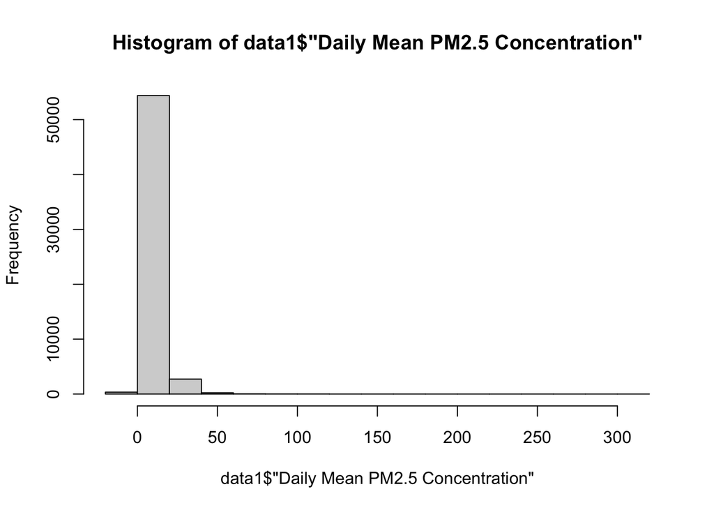

```r
hist(data1$"Daily Mean PM2.5 Concentration")
```

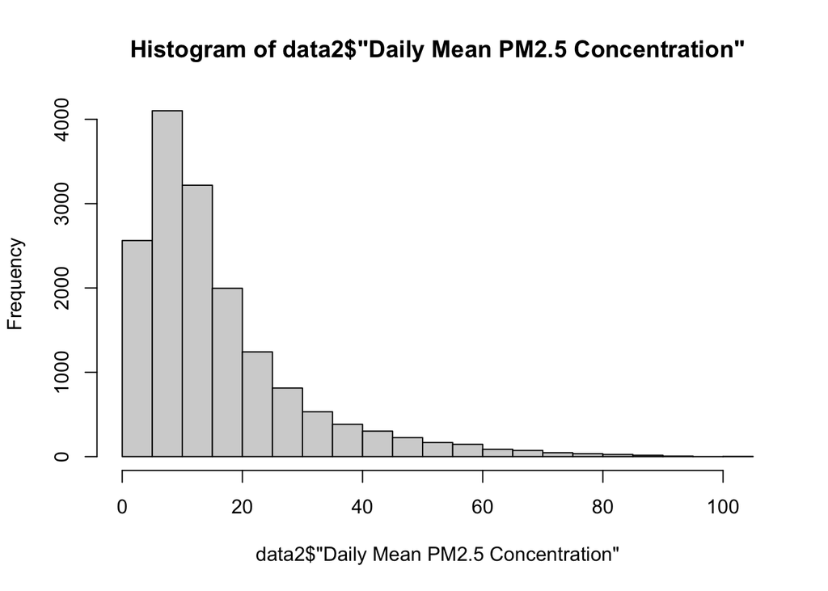

```r
hist(data2$"Daily Mean PM2.5 Concentration")
```

```r
data1 <- data1[order("Daily Mean PM2.5 Concentration")]
head(data1)
```

```
         Date Source  Site ID POC Daily Mean PM2.5 Concentration    UNITS
1: 01/01/2022    AQS 60010007   3                           12.7 ug/m3 LC
   DAILY_AQI_VALUE Site Name DAILY_OBS_COUNT PERCENT_COMPLETE
1:              52 Livermore               1              100
   AQS_PARAMETER_CODE       AQS_PARAMETER_DESC CBSA_CODE
1:              88101 PM2.5 - Local Conditions     41860
                           CBSA_NAME STATE_CODE      STATE COUNTY_CODE  COUNTY
1: San Francisco-Oakland-Hayward, CA          6 California           1 Alameda
   SITE_LATITUDE SITE_LONGITUDE
1:      37.68753      -121.7842
```

```r
tail(data1)
```

```
         Date Source  Site ID POC Daily Mean PM2.5 Concentration    UNITS
1: 01/01/2022    AQS 60010007   3                           12.7 ug/m3 LC
   DAILY_AQI_VALUE Site Name DAILY_OBS_COUNT PERCENT_COMPLETE
1:              52 Livermore               1              100
   AQS_PARAMETER_CODE       AQS_PARAMETER_DESC CBSA_CODE
1:              88101 PM2.5 - Local Conditions     41860
                           CBSA_NAME STATE_CODE      STATE COUNTY_CODE  COUNTY
1: San Francisco-Oakland-Hayward, CA          6 California           1 Alameda
   SITE_LATITUDE SITE_LONGITUDE
1:      37.68753      -121.7842
```

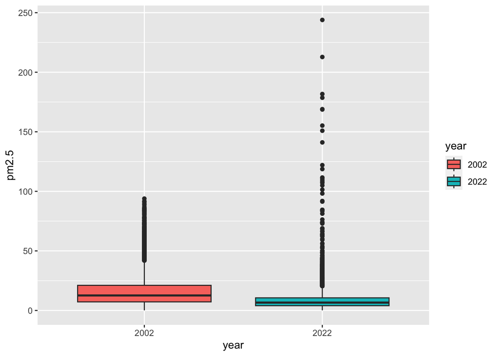

```r
datanew[!is.na(year)] %>%
  ggplot()+
  geom_boxplot(mapping=aes(x=year, y=pm2.5, fill=year))
```

At the County Level:

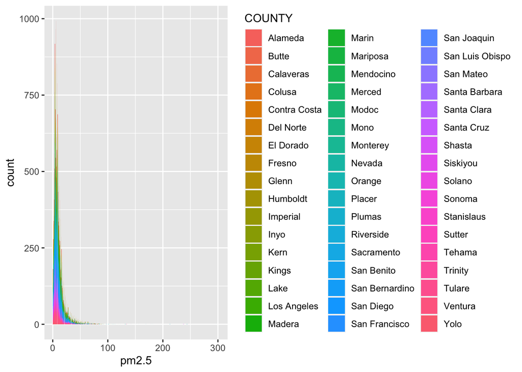

```r
datanew[!is.na(COUNTY)] %>%
  ggplot() +
  geom_bar(mapping = aes(x = pm2.5, fill = COUNTY))
```

```r
county2022 <- data.frame(Variable1=data1$COUNTY, Variable2= data1$"Daily Mean PM2.5 Concentration")
county2022
```

```
  Variable1 Variable2
1   Alameda      12.7
```

```r
county2002 <- data.frame(Variable1=data2$COUNTY, Variable2= data2$"Daily Mean PM2.5 Concentration")
county2002
```

```
            Variable1 Variable2
1             Alameda      25.1
2             Alameda      31.6
3             Alameda      21.4
4             Alameda      25.9
5             Alameda      34.5
6             Alameda      41.0
7             Alameda      29.3
8             Alameda      15.0
9             Alameda      18.8
10            Alameda      37.9
11            Alameda      37.2
12            Alameda       8.6
13            Alameda      26.3
14            Alameda      21.2
```

[output cut: 15962 more lines]

At the site level in Los Angeles

```r
la <- data3[data3$COUNTY == "Los Angeles",]
la
```

```
            Date Source       ID POC pm2.5    UNITS DAILY_AQI_VALUE
   1: 01/01/2002    AQS 60370002   1  32.3 ug/m3 LC              93
   2: 01/01/2002    AQS 60371103   1  39.6 ug/m3 LC             111
   3: 01/01/2002    AQS 60374002   1  47.1 ug/m3 LC             130
   4: 01/01/2022    AQS 60370016   3   5.5 ug/m3 LC              23
   5: 01/01/2022    AQS 60371103   1  11.4 ug/m3 LC              48
  ---
7009: 12/31/2022    AQS 60374008   3   3.7 ug/m3 LC              15
7010: 12/31/2022    AQS 60374009   1   1.5 ug/m3 LC               6
7011: 12/31/2022    AQS 60374009   3  -1.1 ug/m3 LC               0
7012: 12/31/2022    AQS 60374010   3   3.1 ug/m3 LC              13
7013: 12/31/2022    AQS 60376012   3   2.5 ug/m3 LC              10
                           Site Name DAILY_OBS_COUNT PERCENT_COMPLETE
   1:                          Azusa               1              100
   2:  Los Angeles-North Main Street               1              100
```

[output cut: 45 more lines]

**used chat gpt to assist in modifying this original code: la <- data.frame(data3$County == “Los Angeles”)

```r
newsite <-la$"Site Name"
```

```r
library(leaflet)
library(viridis)

# Generating a color palette
ID.pal <- colorFactor(viridis(7), la$newsite)


lamap <- leaflet(la) %>%
  # The looks of the Map
  addProviderTiles('CartoDB.Positron') %>%
  # Some circles
  addCircleMarkers(
    lat = ~latit, lng=~long, fillColor = ~ID.pal(newsite),
    stroke=FALSE,
   fillOpacity = 1,
    ) %>%
  # And a pretty legend
  addLegend('bottomleft', pal=ID.pal, values= ~newsite,
          title='Los Angeles Sites', opacity=1)
lamap
```

[interactive chart not shown]

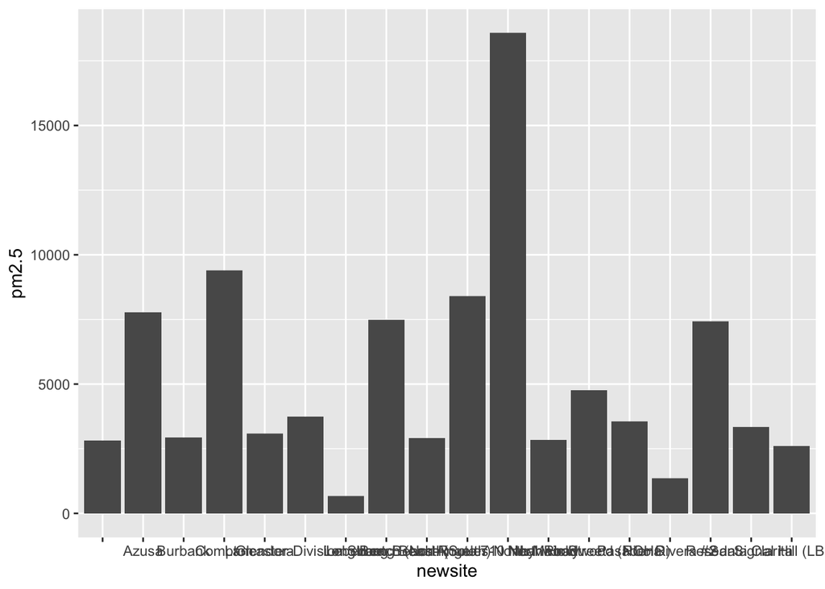

```r
ggplot(la, aes(x=newsite, y= pm2.5)) +
     geom_bar(stat='identity')
```

```r
arrange(la, pm2.5, newsite)
```

```
            Date Source       ID POC pm2.5    UNITS DAILY_AQI_VALUE
   1: 09/11/2022    AQS 60374009   3  -1.2 ug/m3 LC               0
   2: 12/31/2022    AQS 60374009   3  -1.1 ug/m3 LC               0
   3: 11/25/2022    AQS 60370016   3  -0.8 ug/m3 LC               0
   4: 12/25/2022    AQS 60370016   3  -0.8 ug/m3 LC               0
   5: 12/30/2022    AQS 60374009   3  -0.5 ug/m3 LC               0
  ---
7009: 01/02/2002    AQS 60374002   1  62.7 ug/m3 LC             155
7010: 01/02/2002    AQS 60371002   1  63.0 ug/m3 LC             155
7011: 01/02/2002    AQS 60371301   1  64.0 ug/m3 LC             155
7012: 10/15/2002    AQS 60371103   1  66.3 ug/m3 LC             157
7013: 10/15/2002    AQS 60370002   1  72.4 ug/m3 LC             160
                          Site Name DAILY_OBS_COUNT PERCENT_COMPLETE
   1:            Signal Hill (LBSH)               1              100
   2:            Signal Hill (LBSH)               1              100
```

[output cut: 45 more lines]